# Assignment 2 – K-NN Classification

Inn Kyung Seo

2025-09-28

```r
bank <- read.csv("C:/Users/beyou/Desktop/UniversalBank.csv")
head(bank)
```

```
##   ID Age Experience Income ZIP.Code Family CCAvg Education Mortgage
## 1  1  25          1     49    91107      4   1.6         1        0
## 2  2  45         19     34    90089      3   1.5         1        0
## 3  3  39         15     11    94720      1   1.0         1        0
## 4  4  35          9    100    94112      1   2.7         2        0
## 5  5  35          8     45    91330      4   1.0         2        0
## 6  6  37         13     29    92121      4   0.4         2      155
##   Personal.Loan Securities.Account CD.Account Online CreditCard
## 1             0                  1          0      0          0
## 2             0                  1          0      0          0
## 3             0                  0          0      0          0
## 4             0                  0          0      0          0
## 5             0                  0          0      0          1
## 6             0                  0          0      1          0
```

```r
bank <- bank[, !(names(bank) %in% c("ID", "ZIP.Code"))]
head(bank)
```

```
##   Age Experience Income Family CCAvg Education Mortgage Personal.Loan
## 1  25          1     49      4   1.6         1        0             0
## 2  45         19     34      3   1.5         1        0             0
## 3  39         15     11      1   1.0         1        0             0
## 4  35          9    100      1   2.7         2        0             0
## 5  35          8     45      4   1.0         2        0             0
## 6  37         13     29      4   0.4         2      155             0
##   Securities.Account CD.Account Online CreditCard
## 1                  1          0      0          0
## 2                  1          0      0          0
## 3                  0          0      0          0
## 4                  0          0      0          0
## 5                  0          0      0          1
## 6                  0          0      1          0
```

```r
library(fastDummies)

bank <- dummy_cols(bank,
                   select_columns = "Education",
                   remove_first_dummy = FALSE,
                   remove_selected_columns = TRUE)

head(bank)
```

```
##   Age Experience Income Family CCAvg Mortgage Personal.Loan Securities.Account
## 1  25          1     49      4   1.6        0             0                  1
## 2  45         19     34      3   1.5        0             0                  1
## 3  39         15     11      1   1.0        0             0                  0
## 4  35          9    100      1   2.7        0             0                  0
## 5  35          8     45      4   1.0        0             0                  0
## 6  37         13     29      4   0.4      155             0                  0
##   CD.Account Online CreditCard Education_1 Education_2 Education_3
## 1          0      0          0           1           0           0
## 2          0      0          0           1           0           0
## 3          0      0          0           1           0           0
## 4          0      0          0           0           1           0
## 5          0      0          1           0           1           0
## 6          0      1          0           0           1           0
```

```r
set.seed(1)
n <- nrow(bank)
train_index <- sample(1:n, n * 0.6)

train <- bank[train_index, ]
valid <- bank[-train_index, ]

nrow(train)
```

```
## [1] 3000
```

```r
nrow(valid)
```

```
## [1] 2000
```

```r
library(class)
```

```r
train_X <- train %>% select(-Personal.Loan)
train_Y <- train$Personal.Loan

valid_X <- valid %>% select(-Personal.Loan)
valid_Y <- valid$Personal.Loan
```

```r
new_customer <- data.frame(
  Age = 40,
  Experience = 10,
  Income = 84,
  Family = 2,
  CCAvg = 2,
  Mortgage = 0,
  Securities.Account = 0,
  CD.Account = 0,
  Online = 1,
  CreditCard = 1,
  Education_1 = 0,
  Education_2 = 1,
  Education_3 = 0
)
```

```r
knn_pred1 <- knn(train = train_X, test = new_customer, cl = train_Y, k = 1, prob = TRUE)
knn_pred1
```

```
## [1] 0
## attr(,"prob")
## [1] 1
## Levels: 0 1
```

**1. k = 1 Classification for the New Customer**

Using k-NN with k = 1, the model predicted that the new customer belongs to: Class 0 (will not accept the loan) The predicted class probability was 1.0, indicating that the nearest neighbor is entirely from class 0.

```r
k_values <- seq(1, 15, by = 2)
```

```r
valid_error <- rep(0, length(k_values))

for (i in 1:length(k_values)) {
  knn_pred <- knn(train = train_X, test = valid_X, cl = train_Y, k = k_values[i])
  valid_error[i] <- mean(knn_pred != valid_Y)
}
```

```r
k_results <- data.frame(k = k_values, Validation_Error = valid_error)
k_results
```

```
##    k Validation_Error
## 1  1           0.1075
## 2  3           0.1005
## 3  5           0.1045
## 4  7           0.1040
## 5  9           0.1050
## 6 11           0.0995
## 7 13           0.1020
## 8 15           0.1030
```

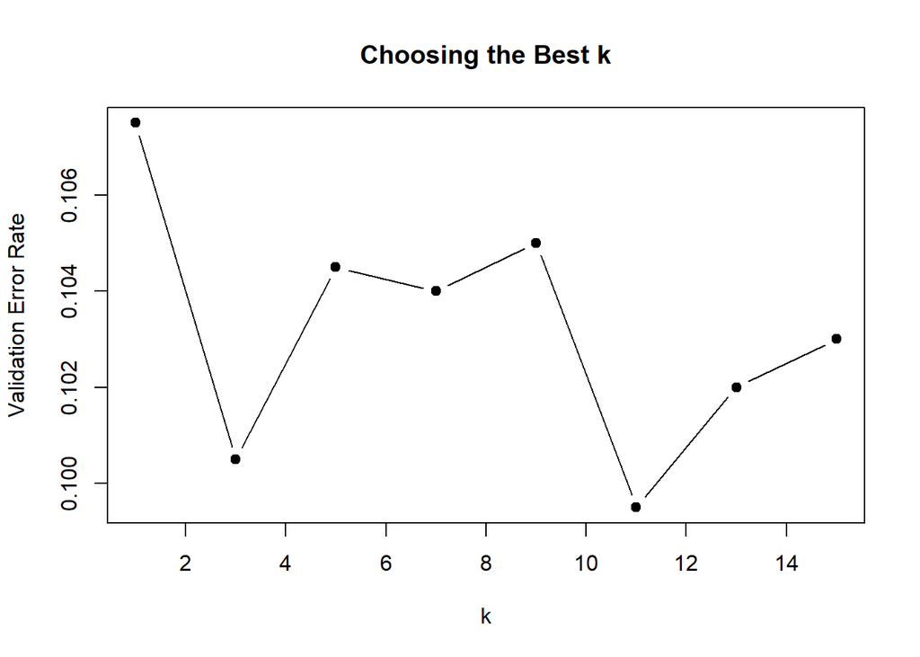

```r
plot(k_values, valid_error, type = "b", pch = 19,
     xlab = "k", ylab = "Validation Error Rate",
     main = "Choosing the Best k")
```

**2. Choosing the Best k**

The validation error was evaluated across multiple k values using the validation dataset. The smallest validation error (0.0995) occurred at k = 11, suggesting that this value achieves a good compromise between model complexity and generalization performance.

```r
best_k <- 11
knn_pred_best <- knn(train = train_X, test = valid_X, cl = train_Y, k = best_k)
```

```r
table(Predicted = knn_pred_best, Actual = valid_Y)
```

```
##          Actual
## Predicted    0    1
##         0 1754  158
##         1   41   47
```

**3. Confusion Matrix for the Validation Data** The confusion matrix below summarizes the classification results on the validation set using k = 11. The model correctly classified 1,754 customers who did not accept the loan and 47 customers who did. However, there were 158 false negatives (actual loan customers misclassified as non-loan) and 41 false positives. Overall, the model demonstrates strong performance in identifying customers who will not accept the loan, though it shows some limitations in correctly classifying customers who actually accepted the loan.

```r
knn_pred_best_customer <- knn(
  train = train_X,
  test = new_customer,
  cl = train_Y,
  k = best_k,
  prob = TRUE
)
```

```r
knn_pred_best_customer
```

```
## [1] 0
## attr(,"prob")
## [1] 1
## Levels: 0 1
```

```r
attr(knn_pred_best_customer, "prob")
```

```
## [1] 1
```

**4. Classification for the New Customer Using the Best k** With k = 11, the model classified the new customer as Class 0 (will not accept the loan). The predicted class probability was 1.0, meaning that all 11 nearest neighbors belonged to class 0. This result indicates a high level of confidence in the model’s prediction for this customer.

```r
set.seed(1)
n <- nrow(bank)
train_index <- sample(1:n, n * 0.5)
temp_data <- bank[-train_index, ]

valid_index <- sample(1:nrow(temp_data), nrow(temp_data) * 0.6)
train <- bank[train_index, ]
valid <- temp_data[valid_index, ]
test <- temp_data[-valid_index, ]

nrow(train); nrow(valid); nrow(test)
```

```
## [1] 2500
```

```
## [1] 1500
```

```
## [1] 1000
```

```r
train_X <- train %>% select(-Personal.Loan)
train_Y <- train$Personal.Loan

valid_X <- valid %>% select(-Personal.Loan)
valid_Y <- valid$Personal.Loan

test_X <- test %>% select(-Personal.Loan)
test_Y <- test$Personal.Loan
```

```r
best_k <- 11
```

```r
knn_pred_train <- knn(train = train_X, test = train_X, cl = train_Y, k = best_k)
train_conf_mat <- table(Predicted = knn_pred_train, Actual = train_Y)
train_conf_mat
```

```
##          Actual
## Predicted    0    1
##         0 2235  159
##         1   33   73
```

```r
knn_pred_valid <- knn(train = train_X, test = valid_X, cl = train_Y, k = best_k)
valid_conf_mat <- table(Predicted = knn_pred_valid, Actual = valid_Y)
valid_conf_mat
```

```
##          Actual
## Predicted    0    1
##         0 1334   98
##         1   30   38
```

```r
knn_pred_test <- knn(train = train_X, test = test_X, cl = train_Y, k = best_k)
test_conf_mat <- table(Predicted = knn_pred_test, Actual = test_Y)
test_conf_mat
```

```
##          Actual
## Predicted   0   1
##         0 862  89
##         1  26  23
```

**Coclusion** In conclusion, the model performs well in identifying customers who will not accept the loan but struggles to correctly classify those who will. This analysis highlights both the strengths and limitations of the k-NN model in handling imbalanced data. Addressing class imbalance through techniques such as oversampling or undersampling, as well as exploring alternative classification models, could lead to better predictive performance for loan acceptance.